# Computer vision & CNNs: Transfer Learning

In this module, we are going to use a pretrained CNN model to perform image classification on our dogs vs. cats images.

Learning objectives:

- Why using pretrained models can be efficient and effective.
- How to perform feature extraction with pretrained models.
- How you can fine tune a pretrained model and run end-to-end.

# Part 1: Data Preparation

We are working with the same dogs and cats images as before.

## Image location

```r
# define the directories:
image_dir <- here::here("docs", "data", "dogs-vs-cats")
train_dir <- file.path(image_dir, "train")
valid_dir <- file.path(image_dir, "validation")
test_dir <- file.path(image_dir, "test")
```

# Applying a pretrained CNN model

There are *two main ways* we can apply a pretrained model to perform a CNN:

1. Feature extraction
2. Fine tune a pretrained model and run end-to-end

## Option 1: Feature extraction

### Get our pretrained model

There are several pretrained models available via keras; they all start with `application_`. Here we’ll use the VGG16 model; it is intuitive to understand the model structure and it does a good job with this task.

- `weights`: Represents the weights to use. Most pretrained models are built on imagenet and using these weights tends to do well.
- `include_top`: Whether to include the fully-connected dense classifier. Typically, we want the classifier to be specific to our problem.
- `input_shape`: The shape of our nputs (150x150 pixel images w/3 color channels).

```r
conv_base <- application_vgg16(
  weights = "imagenet",
  include_top = FALSE,
  input_shape = c(150, 150, 3)
)
```

```r
conv_base
```

```
Model
Model: "vgg16"
____________________________________________________________________________________________________________________________
Layer (type)                                           Output Shape                                      Param #
============================================================================================================================
input_1 (InputLayer)                                   [(None, 150, 150, 3)]                             0
____________________________________________________________________________________________________________________________
block1_conv1 (Conv2D)                                  (None, 150, 150, 64)                              1792
____________________________________________________________________________________________________________________________
block1_conv2 (Conv2D)                                  (None, 150, 150, 64)                              36928
____________________________________________________________________________________________________________________________
block1_pool (MaxPooling2D)                             (None, 75, 75, 64)                                0
____________________________________________________________________________________________________________________________
block2_conv1 (Conv2D)                                  (None, 75, 75, 128)                               73856
____________________________________________________________________________________________________________________________
block2_conv2 (Conv2D)                                  (None, 75, 75, 128)                               147584
____________________________________________________________________________________________________________________________
block2_pool (MaxPooling2D)                             (None, 37, 37, 128)                               0
____________________________________________________________________________________________________________________________
block3_conv1 (Conv2D)                                  (None, 37, 37, 256)                               295168
____________________________________________________________________________________________________________________________
block3_conv2 (Conv2D)                                  (None, 37, 37, 256)                               590080
____________________________________________________________________________________________________________________________
block3_conv3 (Conv2D)                                  (None, 37, 37, 256)                               590080
____________________________________________________________________________________________________________________________
block3_pool (MaxPooling2D)                             (None, 18, 18, 256)                               0
____________________________________________________________________________________________________________________________
block4_conv1 (Conv2D)                                  (None, 18, 18, 512)                               1180160
____________________________________________________________________________________________________________________________
block4_conv2 (Conv2D)                                  (None, 18, 18, 512)                               2359808
____________________________________________________________________________________________________________________________
block4_conv3 (Conv2D)                                  (None, 18, 18, 512)                               2359808
____________________________________________________________________________________________________________________________
block4_pool (MaxPooling2D)                             (None, 9, 9, 512)                                 0
____________________________________________________________________________________________________________________________
block5_conv1 (Conv2D)                                  (None, 9, 9, 512)                                 2359808
____________________________________________________________________________________________________________________________
block5_conv2 (Conv2D)                                  (None, 9, 9, 512)                                 2359808
____________________________________________________________________________________________________________________________
block5_conv3 (Conv2D)                                  (None, 9, 9, 512)                                 2359808
____________________________________________________________________________________________________________________________
block5_pool (MaxPooling2D)                             (None, 4, 4, 512)                                 0
============================================================================================================================
Total params: 14,714,688
Trainable params: 14,714,688
Non-trainable params: 0
____________________________________________________________________________________________________________________________
```

### Extracting features using the pretrained convolutional base

**Without a GPU this will take approximately 5 minutes to execute**

### Reshape features

The extracted features will be a 4D tensor (samples, 4, 4, 512). We can see this in the last layer of our `conv_base` model above (`block5_pool (MaxPooling2D)`).

Consequently, we need to reshape (flatten) these into a 2D tensor to feed into a densely connected classifier. This results in a 2D tensor of size (samples, 4 * 4 * 512 = 8192).

```r
reshape_features <- function(features) {
  array_reshape(features, dim = c(nrow(features), 4 * 4 * 512))
}
train$features <- reshape_features(train$features)
validation$features <- reshape_features(validation$features)
test$features <- reshape_features(test$features)

dim(train$features)
```

```
[1] 2000 8192
```

### Define densely connected classifier model

Here we only need the densely connected classifier.

```r
model <- keras_model_sequential() %>%
  layer_dense(units = 256, activation = "relu", input_shape = 4 * 4 * 512) %>%
  layer_dropout(rate = 0.5) %>%
  layer_dense(units = 1, activation = "sigmoid")

model
```

```
Model
Model: "sequential_11"
____________________________________________________________________________________________________________________________
Layer (type)                                           Output Shape                                      Param #
============================================================================================================================
dense_29 (Dense)                                       (None, 256)                                       2097408
____________________________________________________________________________________________________________________________
dropout_10 (Dropout)                                   (None, 256)                                       0
____________________________________________________________________________________________________________________________
dense_30 (Dense)                                       (None, 1)                                         257
============================================================================================================================
Total params: 2,097,665
Trainable params: 2,097,665
Non-trainable params: 0
____________________________________________________________________________________________________________________________
```

# Plot results:

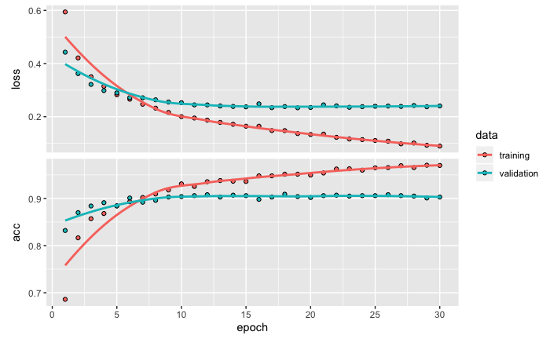

```r
plot(history1)
```

So we acheived a significant decrease in our loss score, increased our accuracy to 90%, and did so in a fraction of the time!

# ————————- ONLY RUN ON GPU!! ———————————-

The above approach performed pretty well. However, we can see that we are still overfitting, which may be reducing model performance. An alternative approach is to run a pretrained model from end-to-end. This approach is much slower and computationally intense; however, it offers greater flexibility in using and adjusting the pretrained model because it lets you:

1. use data augmentation to decrease overfitting (and usually increase model performance).
2. fine tune parts of the pretrained model.

## Option 2a: Run end-to-end with data augmentation

The following approach simply plugs the pretrained convolution base into a sequential model but freezes the convolution base weights.

### Combining a densely-connected neural network with the convolutional base

In this case we can literally plug in our `conv_base` within our model architecture.

**To run the code chunks in this section change `eval=TRUE`**

```r
model <- keras_model_sequential() %>%
  conv_base %>%
  layer_flatten() %>%
  layer_dense(units = 256, activation = "relu") %>%
  layer_dense(units = 1, activation = "sigmoid")

model
```

```
Model
Model: "sequential_12"
____________________________________________________________________________________________________________________________
Layer (type)                                           Output Shape                                      Param #
============================================================================================================================
vgg16 (Model)                                          (None, 4, 4, 512)                                 14714688
____________________________________________________________________________________________________________________________
flatten_3 (Flatten)                                    (None, 8192)                                      0
____________________________________________________________________________________________________________________________
dense_31 (Dense)                                       (None, 256)                                       2097408
____________________________________________________________________________________________________________________________
dense_32 (Dense)                                       (None, 1)                                         257
============================================================================================================================
Total params: 16,812,353
Trainable params: 16,812,353
Non-trainable params: 0
____________________________________________________________________________________________________________________________
```

### Freezing

Before you compile and train the model, it’s important to freeze the convolutional base weights. This prevents the weights from being updated during training. If you don’t do this then the representations found in the pretrained model will be modified and, potentially, completely destroyed.

```r
cat(length(model$trainable_weights), "trainable weight tensors before freezing.\n")
```

[output not shown]

```r
freeze_weights(conv_base)

cat(length(model$trainable_weights), "trainable weight tensors before freezing.\n")
```

```
4 trainable weight tensors before freezing.
```

#### Training the model end-to-end with a frozen convolutional base

The following trains the model end-to-end using all CNN logic that you have seen before:

1. data augmentation
2. image generator
3. compile our model
4. train our model

**To run this code chunk change `eval=TRUE`**

```r
train_datagen = image_data_generator(
  rescale = 1/255,
  rotation_range = 40,
  width_shift_range = 0.2,
  height_shift_range = 0.2,
  shear_range = 0.2,
  zoom_range = 0.2,
  horizontal_flip = TRUE,
  fill_mode = "nearest"
)

test_datagen <- image_data_generator(rescale = 1/255)

train_generator <- flow_images_from_directory(
  train_dir,
  train_datagen,
  target_size = c(150, 150),
  batch_size = 20,
  class_mode = "binary"
)

validation_generator <- flow_images_from_directory(
  validation_dir,
  test_datagen,
  target_size = c(150, 150),
  batch_size = 20,
  class_mode = "binary"
)

model %>% compile(
  loss = "binary_crossentropy",
  optimizer = optimizer_rmsprop(lr = 1e-5),
  metrics = c("accuracy")
)

history2 <- model %>% fit_generator(
  train_generator,
  steps_per_epoch = 100,
  epochs = 30,
  validation_data = validation_generator,
  validation_steps = 50
)
```

#### View history

```r
plot(history2)
```

Another widely used technique for using pretrained models, is to unfreeze a few of the convolutional base and allow those weights to be updated. Recall that the early layers in a CNN identify detailed edges and shapes. Later layers put these edges and shapes together to make higher order parts of the images we are trying to classify (i.e. cat ears, dog tails).

The more our images deviate from the images used to create the pretrained model, then the more likely you will want to retrain the last few layers, which will make the edge and shape features more relevant to your problem.

To fine-tune a pretrained model you:

1. Add your custom network on top of an already-trained base network (executed in the `CNN-base-and-classifier` code chunk).
2. Freeze the base network (executed in the `freeze-parameters` code chunk).
3. Train the part you added (executed in the `train-end-to-end` code chunk).
4. Unfreeze some layers in the base network.
5. Jointly train both these layers and the part you added.

We already did steps 1-3. The following executes steps 4 and 5.

### Unfreeze some layers in the base network

```r
unfreeze_weights(conv_base, from = "block3_conv1")
```

### Jointly train both these layers and the part you added

**To run this code chunk change `eval=TRUE`**

```r
model %>% compile(
  loss = "binary_crossentropy",
  optimizer = optimizer_rmsprop(lr = 1e-5),
  metrics = c("accuracy")
)

history2 <- model %>% fit_generator(
  train_generator,
  steps_per_epoch = 100,
  epochs = 100,
  validation_data = validation_generator,
  validation_steps = 50
)
```